# Model_building

Will Burton

September 17, 2016

### This analysis will cover two main parts

#### 1. Model Building

#### 2. Model Validation

#### 1. Model Building

For model building we build 4 candidate models using forward backward and best subset selection.  
Each model was found by maximizing AIC.

```r
library(dplyr)
library(ggplot2)
library(pROC)
library(caret)
library(tidyr)


df <- read.csv('../data/build.csv')
names(df) <- tolower(names(df))

df$sector <- as.factor(df$sector)

df %>%
  mutate_each(funs(as.factor),c(2,grep('^competitor', names(df))) ) -> df

df$win_bid <- as.factor(ifelse(df$win_bid == "Yes",1,0))

full_logistic_mod <- glm(win_bid ~ . + sector*region_of_country, data = df, family = binomial)

#define empty model
nothing <- glm(win_bid~ 1,data = df, family = binomial)


#preform backwards, forwards, stepwise, and best subset selection, while maximizing AIC
backwards <-step(full_logistic_mod, trace = 0) # Backwards selection is the default
forwards <- step(nothing,
                 scope=list(lower=formula(nothing),upper=formula(full_logistic_mod)), direction="forward", trace = 0)
stepwise <- step(nothing, list(lower=formula(nothing),upper=formula(full_logistic_mod)),
                 direction="both",trace=0)

# best_subset <-  glmulti(formula(full_logistic_mod), data = df,
#                   level = 1,               # Interactions were already added
#                   method = "g",            # genetic algorithm ..exhaustive took forever
#                   crit = "aic",            # AIC as criteria
#                   confsetsize = 5,         # Keep 5 best models
#                   plotty = F, report = F,  # No plot or interim reports
#                   fitfunction = "glm",     # glm function
#                   family = binomial)       # lm function

#the algorithm starts at a different random starting point each time it is ran,
#so I chose the most common output models which also happens to be the same as the backwards selection model
best_subset <- glm(win_bid ~ 1 + sector + region_of_country + competitor_a + competitor_c +
                competitor_f + competitor_h + competitor_j + number_of_competitor_bids +
                row_weight_mult, data = df, family = binomial)
```

#### 2. Model Validation

Out of the four candidate models, there were only two unique models. Stepwise and forwards selection produced the same model formula. Best subset and backwards selection also produced the same model. For model comparison we start out looking at the ROC curves for the two remaining candidate models against the training data

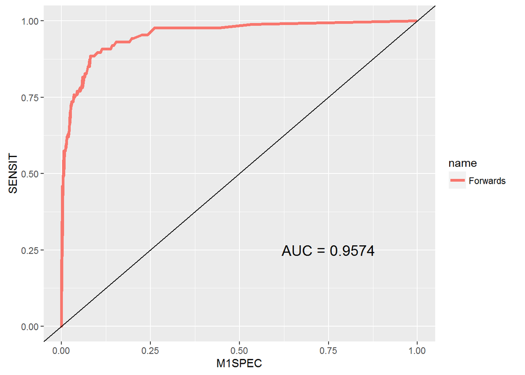

```r
calculate_ROC <- function(model, response, name, probs = NULL, cv = FALSE, i = NULL){
  df <- NULL
  tp_rates <- NULL
  fp_rates <- NULL
  probs <- if(is.null(probs)){predict(model, type= 'response')} else{probs}
  AUC <- as.numeric(auc(response, probs))
    for(threshold in 0:200){
      preds <- ifelse(probs > (threshold/200), 1,0)
      confusion_matrix <- confusionMatrix(preds, response)$table
      POS <- confusion_matrix[2,2]
      NEG <- confusion_matrix[1,1]
      FALPOS <- confusion_matrix[2,1]
      FALNEG <- confusion_matrix[1,2]
      tp_rate <- POS / (POS + FALNEG)
      fp_rate <- FALPOS / (NEG + FALPOS)
      tn_rate <- NEG / (NEG + FALPOS)
      SPECIFICITY  <- tn_rate
      SENSIT <- tp_rate
      M1SPEC <- fp_rate
      df <- rbind(df, data.frame(name, AUC,'PROB' = threshold/200,
                               POS, NEG, FALPOS, FALNEG, SENSIT,
                               M1SPEC, youden_index = (SENSIT + SPECIFICITY - 1),
                               accuracy = (POS + NEG)/(POS + NEG + FALPOS + FALNEG)))

    }
  if(cv == FALSE){
  return(df)
  }else{
      df$cv_iteration <- paste('test', i)
      return(df)
  }
}


forwards_roc <- calculate_ROC(forwards, df$win_bid, 'Forwards')
backwards_roc <- calculate_ROC(backwards, df$win_bid, 'Backwards')

ROCS <- rbind(forwards_roc, backwards_roc)

ggplot(forwards_roc) + geom_line(aes(x = M1SPEC, y = SENSIT, colour = name), size = 1.3) + geom_abline(intercept = 0, slope= 1) +
    annotate("text", label = paste0("AUC = ", round(mean(forwards_roc$AUC),4)), x = .75, y = .25, size = 5, colour = "Black")
```

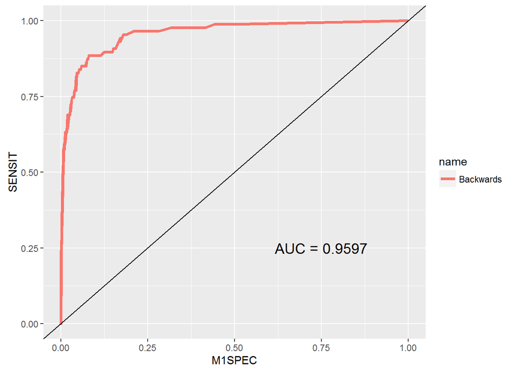

```r
ggplot(backwards_roc) + geom_line(aes(x = M1SPEC, y = SENSIT, colour = name), size = 1.3) +  geom_abline(intercept = 0, slope= 1) +
    annotate("text", label = paste0("AUC = ", round(mean(backwards_roc$AUC),4)), x = .75, y = .25, size = 5, colour = "Black")
```

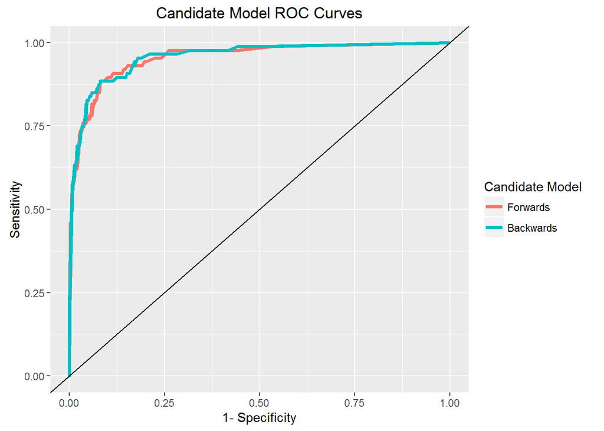

```r
ggplot(ROCS) + geom_line(aes(x = M1SPEC, y = SENSIT, colour = name), size = 1.3) + geom_abline(intercept = 0, slope= 1) + ggtitle('Candidate Model ROC Curves') + xlab('1- Specificity') + ylab('Sensitivity') +
labs(colour='Candidate Model')
```

All candidate model ROC curves are very similar when looking at predictions on the training dataset

Perform a 10-fold validation and display the roc curve for each fold compared to the training dataset. This plot displays the potential variation in the prediction accuracy of future datasets

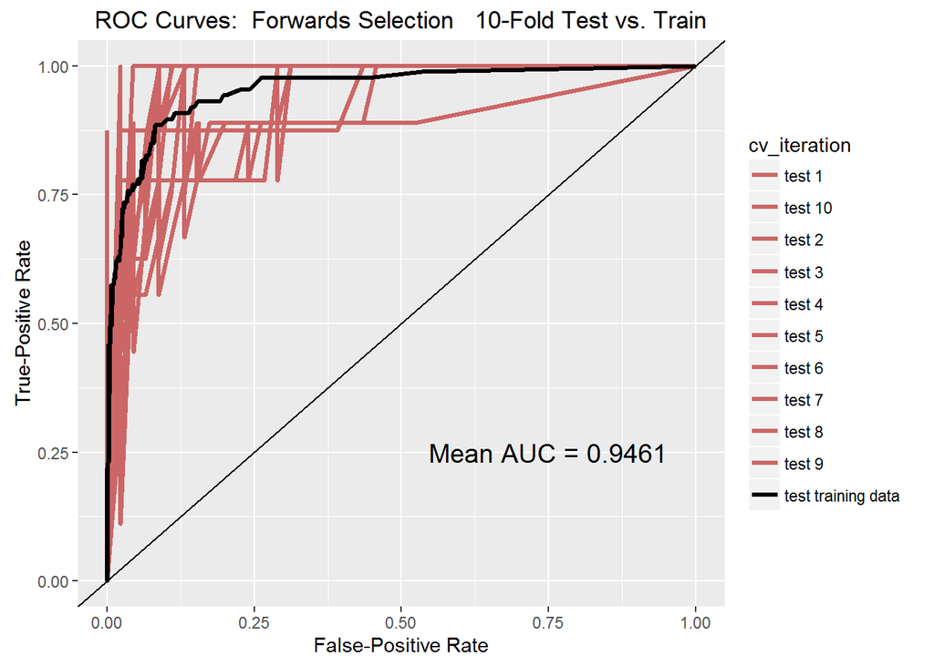

```r
roc_train_test <- function(model, model_title, df, response, n_folds){
  set.seed(10)
  data_folds <- createFolds(response, n_folds)
  rocs <- NULL
  for(i in 1:n_folds){
    temp_model <- glm(formula(model), data = df[unlist(data_folds[-i]),], family = binomial)
    probs <- predict(temp_model, df[data_folds[[i]],], type = 'response')
    outcome <- response[data_folds[[i]]]
    add <- calculate_ROC(model = temp_model, response = outcome,
                         name = 'forward', probs = probs,i = i, cv = TRUE)
    rocs <- rbind(rocs,add)
  }
  add <- calculate_ROC(model = model, response = response,
                       name = 'train', i = 'training data', cv = TRUE)
  rocs_with_train <- rbind(rocs, add)

  d <- ggplot(rocs_with_train, aes(x = M1SPEC, y = SENSIT, colour = cv_iteration)) + geom_line(size = 1.2) + geom_abline(slope = 1, intercept = 0) + xlab("False-Positive Rate") + ylab("True-Positive Rate") + ggtitle(paste("ROC Curves: ",model_title,"  10-Fold Test vs. Train"))
  print(d + scale_color_manual(values=c(rep("#CC6666",n_folds), "#000000")) +
    annotate("text", label = paste0("Mean AUC = ", round(mean(rocs$AUC),4)), x = .75, y = .25, size = 5, colour = "Black"))
}


roc_train_test(forwards, "Forwards Selection", df, df$win_bid, 10)
```

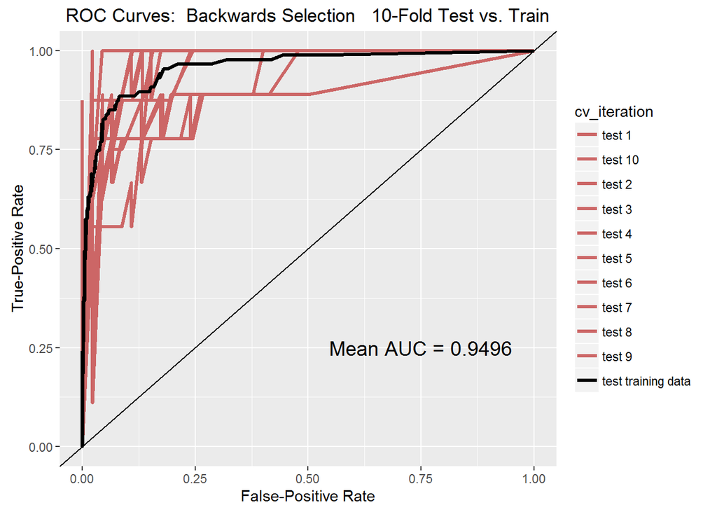

```r
roc_train_test(backwards, "Backwards Selection", df, df$win_bid, 10)
```

The mean AUC when averaged over each test fold for the backwards selection model is 0.9496, while the forwards model was 0.9461

To further validate the models we perform a 10-fold cross-validation repeated 50 times with different training and testing sets, except this time instead of looking ar AUC, we look at max accuracy. We use the thresholds calculated for both the max youden index and max accuracy from the training set for these tests.  
The first plot will display the model accuracy using the max accuracy threshold

```r
#cv with threshold


cv <- function(model, df, threshold, folds= 10, response, times = 50){
  set.seed(5)
  accuracy <- NULL
    for(time in 1:times){
      data_folds <- createFolds(1:nrow(df), k = folds)
      for(fold in data_folds){
        train <- df[-fold,]
        test <- df[fold,]
        mod <- glm(formula(model), data = df, family = 'binomial')
        actual <- response[fold]
        probs <- predict(mod,test, type = 'response')
        preds <- ifelse(probs > threshold, 1,0)
      confusion_matrix2 <- confusionMatrix(preds, actual)
      confusion_matrix <- confusionMatrix(preds, actual)$table
      POS <- confusion_matrix[2,2]
      NEG <- confusion_matrix[1,1]
      FALPOS <- confusion_matrix[2,1]
      FALNEG <- confusion_matrix[1,2]
      tp_rate <- POS / (POS + FALNEG)
      fp_rate <- FALPOS / (NEG + FALPOS)
      tn_rate <- NEG / (NEG + FALPOS)
      SPECIFICITY  <- tn_rate
      SENSIT <- tp_rate
      M1SPEC <- fp_rate
      accuracy <- c(accuracy, confusion_matrix2$overall[1])
      }
    }

return(accuracy)
}



forwards_max_accuracy_threshold <- median(forwards_roc$PROB[forwards_roc$accuracy  == max(forwards_roc$accuracy)])
print(forwards_max_accuracy_threshold)
```

```
## [1] 0.4725
```

```r
backwards_max_accuracy_threshold <- median(backwards_roc$PROB[backwards_roc$accuracy  == max(backwards_roc$accuracy)])
print(backwards_max_accuracy_threshold)
```

```
## [1] 0.37
```

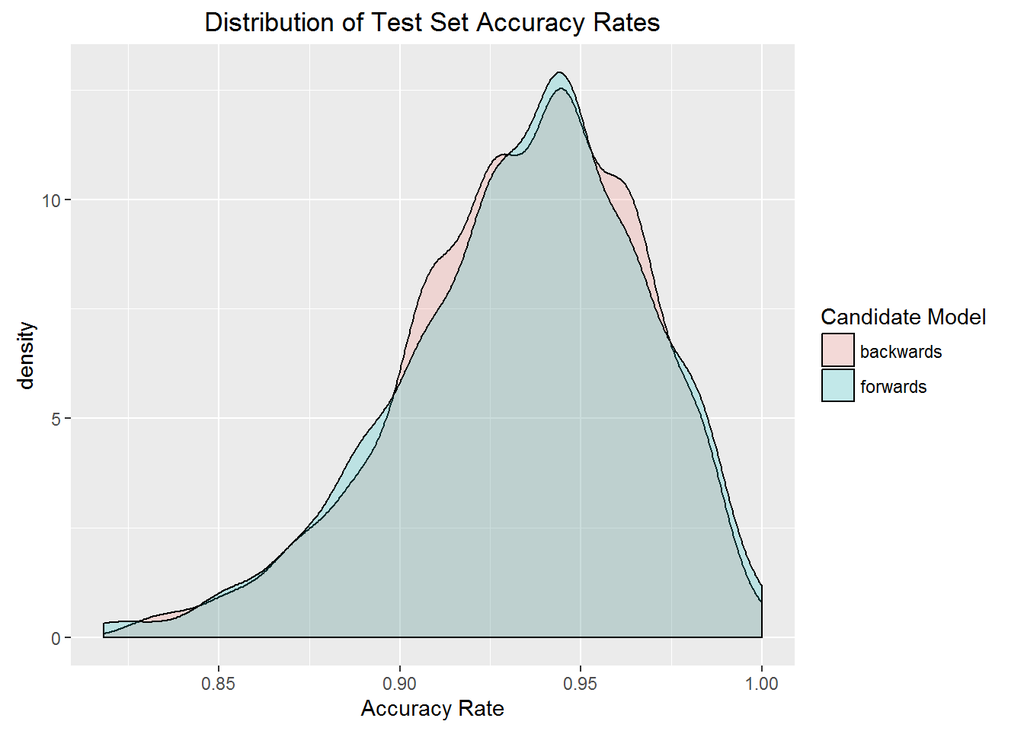

```r
forwards_max_youden_threshold <- median(forwards_roc$PROB[forwards_roc$youden_index  == max(forwards_roc$youden_index)])
backwards_max_youden_threshold <- median(backwards_roc$PROB[backwards_roc$youden_index  == max(backwards_roc$youden_index)])


forwards_accuracy <- cv(forwards, df, threshold = forwards_max_accuracy_threshold, response = df$win_bid)
backwards_accuracy <- cv(backwards, df, threshold = backwards_max_accuracy_threshold , response = df$win_bid)

forwards_youden <- cv(forwards, df, threshold = forwards_max_youden_threshold, response = df$win_bid)
backwards_youden <- cv(backwards, df, threshold = backwards_max_youden_threshold, response = df$win_bid)


data.frame(forwards = forwards_accuracy, backwards = backwards_accuracy) %>%
  gather() -> plot_performance


ggplot(plot_performance) + geom_density(aes(x = value, fill = key), alpha = .2)+ ggtitle('Distribution of Test Set Accuracy Rates') + labs(fill='Candidate Model') + xlab('Accuracy Rate')
```

```r
summary(plot_performance$value[plot_performance$key == 'backwards'])
```

```
##    Min. 1st Qu.  Median    Mean 3rd Qu.    Max.
##  0.8302  0.9091  0.9434  0.9337  0.9623  1.0000
```

```r
summary(plot_performance$value[plot_performance$key == 'forwards'])
```

```
##    Min. 1st Qu.  Median    Mean 3rd Qu.    Max.
##  0.8182  0.9091  0.9434  0.9338  0.9623  1.0000
```

Both the distributions are very similar and When summarizing the accuracy levels the mean accuracy only differs by .01%. The forward model performed the best with an accuracy rate of 93.38%.  
Now we look at the same plot, but this time using the threshold giving the max youden index from the training set.

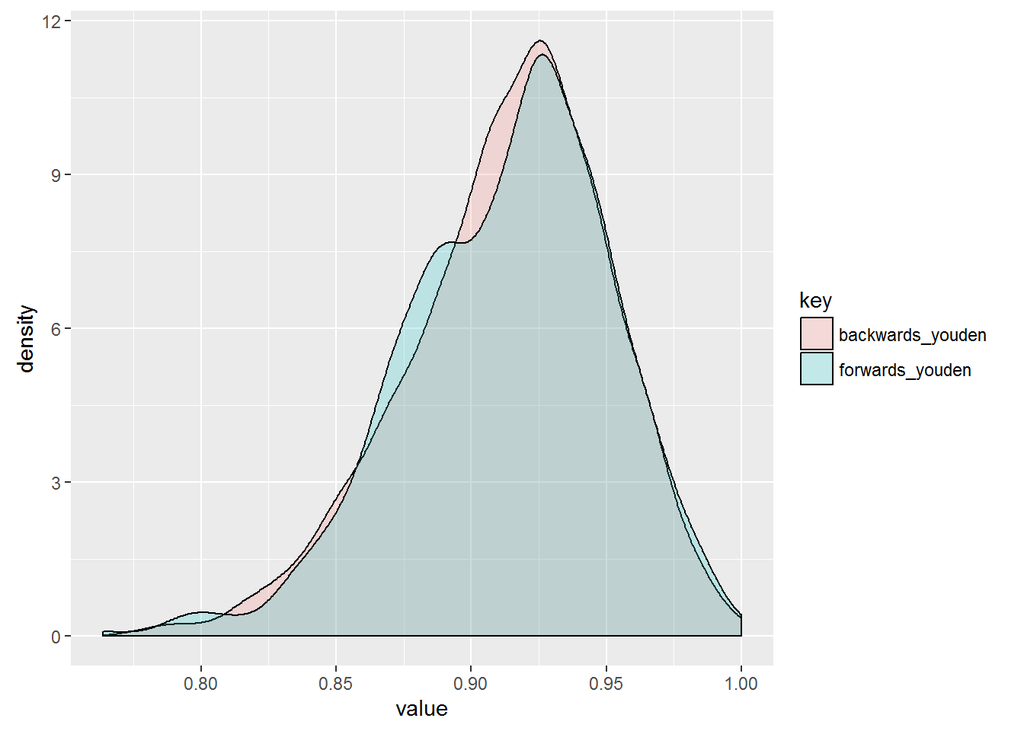

```r
data.frame(forwards_youden, backwards_youden) %>%
  gather() -> plot_youden


ggplot(plot_youden) + geom_density(aes(x = value, fill = key), alpha = .2)
```

```r
summary(plot_youden$value[plot_youden$key == 'backwards_youden'])
```

```
##    Min. 1st Qu.  Median    Mean 3rd Qu.    Max.
##  0.7818  0.8909  0.9245  0.9135  0.9434  1.0000
```

```r
summary(plot_youden$value[plot_youden$key == 'forwards_youden'])
```

```
##    Min. 1st Qu.  Median    Mean 3rd Qu.    Max.
##  0.7636  0.8889  0.9245  0.9135  0.9444  1.0000
```

Using the youden index, both models had the same mean accuracy.

Both the forwards model and backwards models perform extremely similar. In conclusion I would choose the forwards model with average mean performance on test data of 93.38%

```r
formula(forwards)
```

```
## win_bid ~ number_of_competitor_bids + sector + region_of_country +
##     competitor_j + competitor_f + competitor_h + competitor_b +
##     competitor_e + competitor_c
```

```r
formula(backwards)
```

```
## win_bid ~ sector + region_of_country + number_of_competitor_bids +
##     competitor_a + competitor_c + competitor_f + competitor_h +
##     competitor_j + row_weight_mult
```

How many projects can you not apply for and not miss a single win

```r
probs <- predict(forwards, type = 'response')
wins <- data.frame(probs, 'win_bid' = df$win_bid)

confusion_matrix <- function(df, threshold){
  preds <- ifelse(probs > threshold,1,0)
  return(confusionMatrix(preds,df$win_bid)$table)
}

for(i in c(.05,.10,.15,.20,.25,.30)){
  print(confusion_matrix(wins,i))
}
```

```
##           Reference
## Prediction   0   1
##          0 341   3
##          1 115  84
##           Reference
## Prediction   0   1
##          0 381   6
##          1  75  81
##           Reference
## Prediction   0   1
##          0 401   8
##          1  55  79
##           Reference
## Prediction   0   1
##          0 410   9
##          1  46  78
##           Reference
## Prediction   0   1
##          0 419  10
##          1  37  77
##           Reference
## Prediction   0   1
##          0 424  15
##          1  32  72
```

```r
summary(wins$probs[wins$win_bid == 0])
```

```
##      Min.   1st Qu.    Median      Mean   3rd Qu.      Max.
## 0.0000000 0.0006615 0.0068340 0.0632400 0.0500600 0.9694000
```

```r
summary(wins$probs[wins$win_bid == 1])
```

```
##     Min.  1st Qu.   Median     Mean  3rd Qu.     Max.
## 0.001438 0.439700 0.743100 0.668500 0.954900 0.999600
```

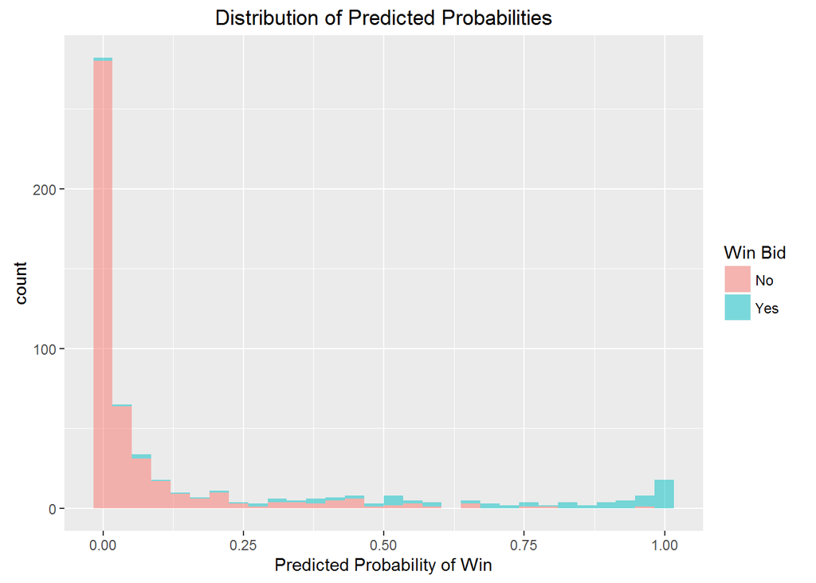

```r
ggplot(wins) + geom_histogram(aes(x = probs, fill = win_bid), alpha = .5) + xlab('Predicted Probability of Win') +
  ggtitle("Distribution of Predicted Probabilities") + scale_fill_discrete(guide_legend(title = "Win Bid"),labels=c("No","Yes"))
```